# Proyecto final

Karla de la Cruz

10/1/2021

#En este trabjao les explicare como puedes realizar y mejorar un trabajo con datos, realizando graficas y matrices en rstudiocloud.

##Como ejemplo para las gráficas se utilizará datos sobre la incidencia delictiva en la ciudad de México.Para esto se utilizaránn las siguientes herramientas.

```r
"matrix"
```

```
## [1] "matrix"
```

```r
"plot"
```

```
## [1] "plot"
```

##Uno de los delitos más frecuentes son el robo o aslato en el transporte público, mediremos si existe algun tipo de cambio desde el año 2010 hasta el 2018

###Para realizar una grafica primero definiriamos el valor del eje x, de donde a donde va.

```r
x<-2010:2018
```

###También el eje y.

```r
y<-1:9
```

###Ahora comenzamos a grafcar con la funcion plot y gx

###Función identidad: `g(x)=x`

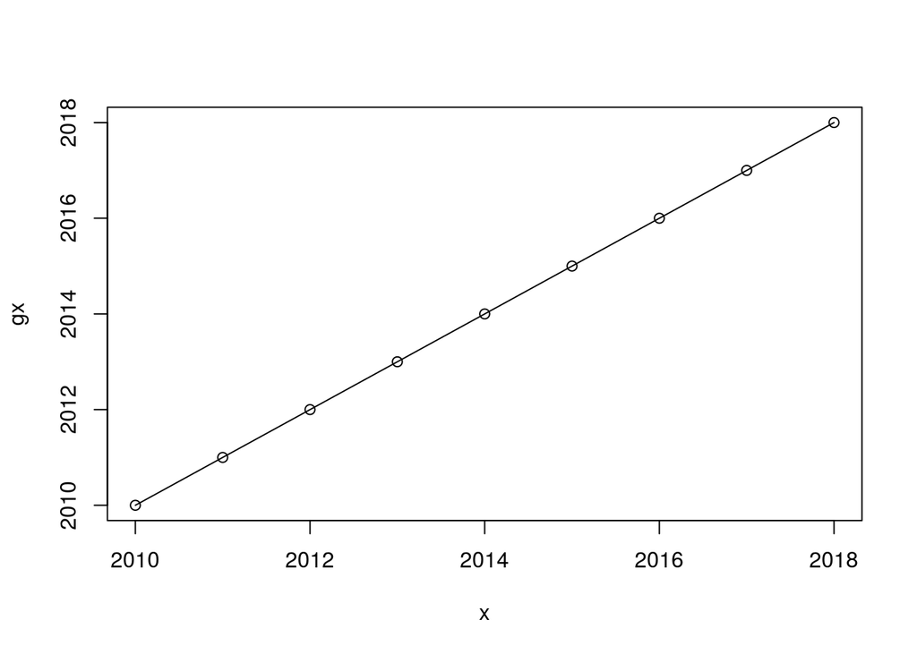

```r
gx<-x
plot(x, gx, type="o")
```

##Para cambiar los nombres de los ejes y definir las cantidades de incidentes delictivos en la Ciudad de México.

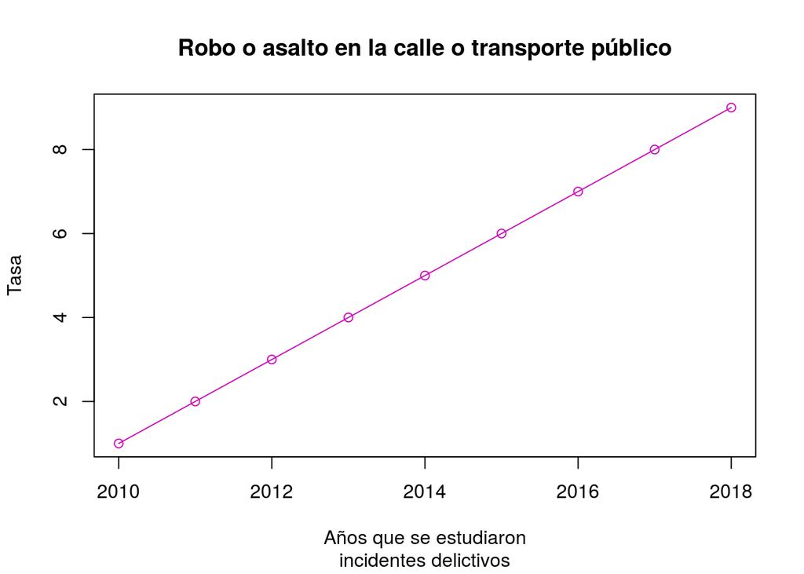

```r
x<-2010:2018
y<-1:9
plot (x,y, main="Robo o asalto en la calle o transporte público", sub="incidentes delictivos",xlab="Años que se estudiaron", ylab="Tasa", col="38", type="o")
```

##Para realizar matrices primero deberas definir de cuantas columans necesitas hacerla. Un ejemplo facil y practico son las matrices de 3x3.

###Aqui utilizaremos la herramienta matrix.

```r
x<-c(1,4,7)
y<-c(2,5,8)
z<-c(3,6,9)
g<-matrix(c(x,y,z),nrow=3)
g
```

```
##      [,1] [,2] [,3]
## [1,]    1    2    3
## [2,]    4    5    6
## [3,]    7    8    9
```

###Ahora cambiaremos el nombre de las columnas.

```r
colnames(g)<-c("Canción","Platillo","Deporte")
```

```r
x<-c("home","enchiladas","voleibol")
y<-c("dembow","cochinita","natación")
g<-rbind(x,y)
colnames(g)<-c("Canción","Platillo","Deporte")
rownames(g)<-c("Fila 1","Fila 2")
g
```

```
##        Canción  Platillo     Deporte
## Fila 1 "home"   "enchiladas" "voleibol"
## Fila 2 "dembow" "cochinita"  "natación"
```

###Las matrices sirven para poder resolver sistemas de ecuaciones lineales, sistemas de ecuaciones diferenciales o representar una aplicación lineal, existen diversos metodos para resolverla.

###En el siguiente video se demostrara un ejercicio practico de resolucion de una matriz inversa.

[video not shown]